# Problem Statement:

An online news portal wants to understand whether a new landing be more effective at drawing new subscribers than the old landing page.

The portal also wants a detailed analysis:

1. Exploratory Data Analysis.
2. Do the users spend more time on the new landing page than the old landing page?
3. Is the conversion rate (the proportion of users who visit the landing page and get converted) for the new page greater than the conversion rate for the old page?
4. Does the converted status depend on the preferred language?
5. Is the mean time spent on the new page same for the different language users?

```python
import numpy as np
import pandas as pd
import matplotlib.pyplot as plt
import scipy.stats as stats
from scipy.stats import ttest_ind
from scipy.stats import chi2_contingency
from scipy.stats import f_oneway
import seaborn as sns

import warnings
warnings.filterwarnings('ignore')

df=pd.read_csv("abtest.csv")
```

# 1. Exploratory Data Analysis

```python
df.head(10)
```

|  | user_id | group | landing_page | time_spent_on_the_page | converted | language_preferred |
| --- | --- | --- | --- | --- | --- | --- |
| 0 | 546592 | control | old | 3.48 | no | Spanish |
| 1 | 546468 | treatment | new | 7.13 | yes | English |
| 2 | 546462 | treatment | new | 4.40 | no | Spanish |
| 3 | 546567 | control | old | 3.02 | no | French |
| 4 | 546459 | treatment | new | 4.75 | yes | Spanish |
| 5 | 546558 | control | old | 5.28 | yes | English |
| 6 | 546448 | treatment | new | 5.25 | yes | French |
| 7 | 546581 | control | old | 6.53 | yes | Spanish |
| 8 | 546461 | treatment | new | 10.71 | yes | French |
| 9 | 546548 | control | old | 2.08 | no | English |

```python
df.shape
```

```
(100, 6)
```

```python
df.info()
```

```
<class 'pandas.core.frame.DataFrame'>
RangeIndex: 100 entries, 0 to 99
Data columns (total 6 columns):
 #   Column                  Non-Null Count  Dtype
---  ------                  --------------  -----
 0   user_id                 100 non-null    int64
 1   group                   100 non-null    object
 2   landing_page            100 non-null    object
 3   time_spent_on_the_page  100 non-null    float64
 4   converted               100 non-null    object
 5   language_preferred      100 non-null    object
dtypes: float64(1), int64(1), object(4)
memory usage: 4.8+ KB
```

```python
df["group"].value_counts()
```

```
control      50
treatment    50
Name: group, dtype: int64
```

Observations: There are 100 portal users in the random sample, with 6 pieces of information collected for each user; 50 users received the old landing page treatment, and 50 users received the new landing page treatment.

- user_id is an integer, but the ID is not numerically meaningful.
- The control group variable is given the old landing page.
- The time spent on the page is a fraction of time, and therefore a float data type.
- The "converted" variable is a binary object describing whether the users converted to subscribers.
- The "language preferred" is on object describing whether the user read the page in English, French or Spanish.

# Univariate Analysis

```python
df.describe()
```

|  | user_id | time_spent_on_the_page |
| --- | --- | --- |
| count | 100.000000 | 100.000000 |
| mean | 546517.000000 | 5.377800 |
| std | 52.295779 | 2.378166 |
| min | 546443.000000 | 0.190000 |
| 25% | 546467.750000 | 3.880000 |
| 50% | 546492.500000 | 5.415000 |
| 75% | 546567.250000 | 7.022500 |
| max | 546592.000000 | 10.710000 |

Observations: The sample mean time spent on boths page of was 5.38 minutes, with a sample standard deviation of 2.38 minutes. The median time spent, 5.41 minutes, is close to the mean, which may indicate a normally distributed time spent on the landing page.

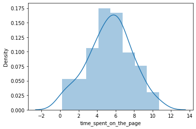

```python
sns.distplot(df["time_spent_on_the_page"]);
```

Observations:The mean time spent on the page appears to follow a normal distribution, regardless of landing page treatment.

```python
df_new=df[df["landing_page"]=="new"]
df_new.head()
```

|  | user_id | group | landing_page | time_spent_on_the_page | converted | language_preferred |
| --- | --- | --- | --- | --- | --- | --- |
| 1 | 546468 | treatment | new | 7.13 | yes | English |
| 2 | 546462 | treatment | new | 4.40 | no | Spanish |
| 4 | 546459 | treatment | new | 4.75 | yes | Spanish |
| 6 | 546448 | treatment | new | 5.25 | yes | French |
| 8 | 546461 | treatment | new | 10.71 | yes | French |

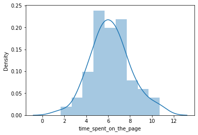

```python
sns.distplot(df_new["time_spent_on_the_page"]);
```

```python
df_new.describe()
```

|  | user_id | time_spent_on_the_page |
| --- | --- | --- |
| count | 50.00000 | 50.000000 |
| mean | 546467.50000 | 6.223200 |
| std | 14.57738 | 1.817031 |
| min | 546443.00000 | 1.650000 |
| 25% | 546455.25000 | 5.175000 |
| 50% | 546467.50000 | 6.105000 |
| 75% | 546479.75000 | 7.160000 |
| max | 546492.00000 | 10.710000 |

Observation: The users of the new landing page, on average, spend 6.22 minutes on the page, with a standard deviation of 1.82 minutes. The minimum time spent on the new page was 1.65 minutes, and the maximum was 10.71 minutes. The median time spent, 6.11 minutes, is close to the mean, which may indicate a normally distributed time spent on the landing page. The distribution plot also confirms a somewhat normal distribution of mean time spent on the new page, as does the number of samples being greater than 30.

```python
df_old=df[df["landing_page"]=="old"]
df_old.head()
```

|  | user_id | group | landing_page | time_spent_on_the_page | converted | language_preferred |
| --- | --- | --- | --- | --- | --- | --- |
| 0 | 546592 | control | old | 3.48 | no | Spanish |
| 3 | 546567 | control | old | 3.02 | no | French |
| 5 | 546558 | control | old | 5.28 | yes | English |
| 7 | 546581 | control | old | 6.53 | yes | Spanish |
| 9 | 546548 | control | old | 2.08 | no | English |

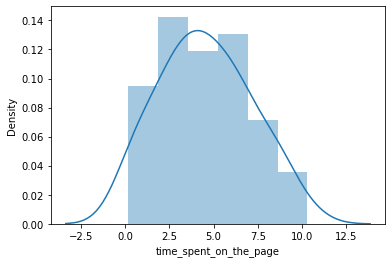

```python
sns.distplot(df_old["time_spent_on_the_page"]);
```

```python
df_old.describe()
```

|  | user_id | time_spent_on_the_page |
| --- | --- | --- |
| count | 50.00000 | 50.000000 |
| mean | 546566.50000 | 4.532400 |
| std | 17.67767 | 2.581975 |
| min | 546493.00000 | 0.190000 |
| 25% | 546555.25000 | 2.720000 |
| 50% | 546567.50000 | 4.380000 |
| 75% | 546579.75000 | 6.442500 |
| max | 546592.00000 | 10.300000 |

Observation: The users of the old landing page, on average, spend 4.53 minutes on the page, with a standard deviation of 2.58 minutes. The minimum time spent on the new page was 0.19 minutes, and the maximum was 10.3 minutes. The median time spent, 4.38 minutes, is close to the mean, which may indicate a normally distributed time spent on the landing page. The distribution plot also confirms a somewhat normal distribution of mean time spent on the old page, possibly with a slight right skew, indicating that the time spent on the old webpage may trend to fewer than 4 minutes. However, we can assume normal distribution because the sample size is greater than 30.

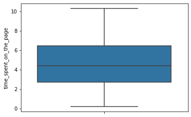

```python
sns.boxplot(y=df_old["time_spent_on_the_page"], data=df_old);
```

Observations: For the old landing page, there are no outliers in time spent on the page. The IQR for the time spent is between 2.72 minutes and 6.44 minutes.

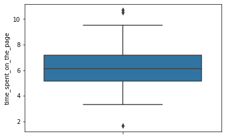

```python
sns.boxplot(y=df_new["time_spent_on_the_page"], data=df_new);
```

Observations: For the new landing page, there are 3 outliers in time spent on the page, including two individuals who spent more than 10 minutes on the pae and 1 individual who spent fewer than 2 minutes on the page. The IQR for the time spent is between 5.18 minutes and 7.16 minutes.

# Multivariate Analysis

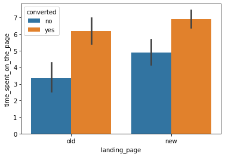

```python
sns.barplot(x="landing_page", y="time_spent_on_the_page",hue="converted", data=df);
```

Observations: Readers, on average, spent more time on the new page than the old page. The readers who were converted to subscribers spent more time on the page, regardless of whether it was old who new.

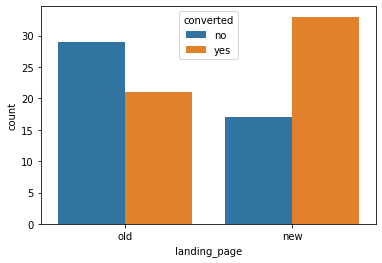

```python
sns.countplot(x="landing_page", hue="converted", data=df);
```

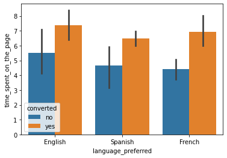

```python
sns.barplot(x="language_preferred",y="time_spent_on_the_page",hue="converted", data=df_new, hue_order=["no", "yes"]);
```

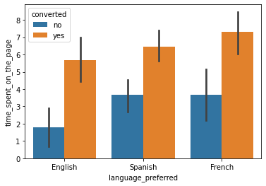

```python
sns.barplot(x="language_preferred",y="time_spent_on_the_page",hue="converted", data=df_old, order=["English", "Spanish","French"]);
```

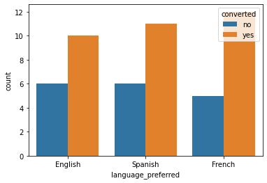

```python
sns.countplot(x="language_preferred", hue="converted", data=df_new, hue_order=["no", "yes"]);
```

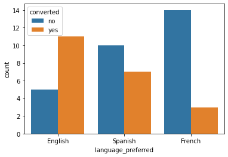

```python
sns.countplot(x="language_preferred", hue="converted", data=df_old, order=["English", "Spanish","French"]);
```

# 2. Do the users spend more time on the new landing page than the old landing page?

Ho: mean time spent on new landing page equals mean time spent on old landing page

```python
sample_mean_old=4.53
sample_std_old=2.58
sample_mean_new=6.22
sample_std_new=1.82
```

We are using a two-sample t-test:

1. Because there are two sample means (old page and new page time spent on each page)
2. The population standard deviation is unknown
3. The time variable is a continuous variable
4. We can assume a normal distribution for both treatment groups because the number of observations is greater than 30 in both groups.

```python
compare_pages=ttest_ind(df_new["time_spent_on_the_page"],df_old["time_spent_on_the_page"],alternative="greater")
compare_pages
```

```
Ttest_indResult(statistic=3.7867702694199856, pvalue=0.0001316123528095005)
```

As the p-value 0.00013 is less than the level of significance a=0.05, we can reject the null hypothesis and conclude with 95% confidence that the mean time spent on the new page is greater than the mean time spent on the old page.

# 3. Is the conversion rate (the proportion of users who visit the landing page and get converted) for the new page greater than the conversion rate for the old page?

Ho: The proportion of converted readers is the same on the new page as it is on the old page

Ha: The proportion of converted readers is greater for the new page than it is on the old page

Because both sample sizes are greater than 30, we can assume normal distributions for both the new page and old page proportion of converted readers. Both the mean (np) and n(1-p) are greater than 10, based on the countplots of converts above, further substantiating that a normal distribution can be applied to the binomial distribution.

The two samples are independent of each other because one reader's landing page treatment does not impact another reader's landing page treatment. They are random samples as well.

For the above reasons, a two-proportion z-test can be used to compare the two sample proportions of converted readers.

```python
df_conversion=pd.crosstab(index=df['converted'], columns=df['landing_page'])
df_conversion
```

| landing_page converted | new | old |
| --- | --- | --- |
| no | 17 | 29 |
| yes | 33 | 21 |

```python
counts=np.array([33,21]) #set the count of converts in new, old landing page
nobs=np.array([50,50]) #set the totals of each sample
```

```python
from statsmodels.stats.proportion import proportions_ztest
```

```python
stat, pval = proportions_ztest(counts, nobs, alternative='larger')
print(pval)
```

```
0.008026308204056278
```

Because the p-value of .008 is less than the significance level of .05, we reject the null hypothesis (that the there is no differnce in conversion rate between the two landing pages) and conclude that the new landing page did have a greater conversion rate than the old landing page.

# 4. Does the converted status depend on the preferred language?

```python
df_lang=pd.crosstab(index=df['converted'], columns=df['language_preferred'])
df_lang
#create a crosstab of converted readers by language
```

| language_preferred converted | English | French | Spanish |
| --- | --- | --- | --- |
| no | 11 | 19 | 16 |
| yes | 21 | 15 | 18 |

Ho: Whether a reader was converted to a subscriber is independent of preferred language

Ha: Reader conversion is not independent of preferred language

```python
c, p, dof, expected=chi2_contingency(df_lang)
print(p)
#Chi squared test for independence between converted and preferred language variables
```

```
0.21298887487543447
```

The p-value of the chi-squared test for independence between the language preferred and the conversion rate is 0.213, which is greater than the required a=.05 requirement. Therefore, we fail to reject the null hypothesis at the 95% confidence level, concluding that whether a reader was converted to a subscriber is independent of the reader's preferred language. Therefore, E-news Express knows with 95% confidence that whether the landing page is in English, French, or Spanish does not impact whether a reader is converted to a subscriber.

# 5. Is the mean time spent on the new page same for the different language users?

Because we are testing multiple sample means from independent populations (English, French, and Spanish speakers' preferred language does not depend on each other), an ANOVA test is most appropriate.

We can assume the mean time spent on the new page is normally distributed because the number of smaple observations is greater than 30.

However, we must first conduct a Levene test to understand if variances are equal or not.

Levene:

Ho:All variances between the time spent on the new pages are equal across all pages. Ha:At least one variance between the time spent on the new pages are not equal across all pages.

```python
from scipy.stats import levene

statistic,p_value=levene(df_new["time_spent_on_the_page"][df_new["language_preferred"]=="English"],
                         df_new["time_spent_on_the_page"][df_new["language_preferred"]=="French"],
                         df_new["time_spent_on_the_page"][df_new["language_preferred"]=="Spanish"])
print(p_value)
```

```
0.46711357711340173
```

Because the p-value of the Levene test is greater than the significance level of a=.05, we fail to reject the null hypothesis and conclude with 95% confidence that variances between the time spent on the new pages are equal across new English, Spanish, and French pages.

We can now proceed with the ANOVA test:

Ho: mean time spent on new English page=mean time mean time spent on new French page=mean time spent on new Spanish page

Ha: at least one mean time spent on the new page is different between the English, French, and Spanish pages

```python
test_stat,p_value=f_oneway(df_new["time_spent_on_the_page"][df_new["language_preferred"]=="English"],
                         df_new["time_spent_on_the_page"][df_new["language_preferred"]=="French"],
                         df_new["time_spent_on_the_page"][df_new["language_preferred"]=="Spanish"])
print(p_value)
```

```
0.43204138694325955
```

Because the p-value of the ANOVA test is greater than the significance level of a=.05, we fail to reject the null hypothesis and conclude with 95% confidence that mean time spent on the new pages are equal across new English, Spanish, and French pages.